Machine Learning

[figure not shown]

# Machine Learning

### 11. Backpropagation (Intro to Deep Learning)

**Prof. Iacopo Masi - Computer Science Department, Sapienza University of Rome**

# Recap previous lecture

- **Multi-Class Classification**
- **SoftMax Regression** plus **Cross-Entropy Loss**
- Optimization in Deep Learing with **SGD over mini-batch with momentum**
- MLP and Fully-Connected Neural Nets
- Intro to Backpropagation

# Today's lecture

## Supervised, Parametric Models

#### Propaedeutic part for Deep Learning

### 0) Go back to Backpropagation

### 1) Backpropagation with matrices and vectors (Jacobians, Gradients)

### 2) End of the course! 🤖 🦿

# This lecture material is taken from

- [d2l.ai - Multi Variable Calculus](https://d2l.ai/chapter_appendix-mathematics-for-deep-learning/multivariable-calculus.html)
- [Karpathy (Tesla Machine Learning Director) Lecture on Backprop](https://www.youtube.com/watch?v=i94OvYb6noo&t=2985s)
- [Stanford Neural Nets and Backprop lecture](https://www.youtube.com/watch?v=mpJ2bFF6o8s)
- [Stanford ML notes on Neural Nets](http://cs229.stanford.edu/summer2019/cs229-notes-deep_learning.pdf)
- [Stanford ML notes on Backprop](http://cs229.stanford.edu/notes-spring2019/backprop.pdf)
- [Animation from jermwatt.github.io](https://jermwatt.github.io/machine_learning_refined/notes/3_First_order_methods/3_8_Momentum.html)

# Now you see why it's named Multi-Layer Perceptron (MLP)

[figure not shown]

# Representation of a Single Layer

Let's consider our linear softmax regressor

$$ \underbrace{\mbf{z}}_{\mathbb{R}^{Kx1}} = \underbrace{\mbf{W}}_{\mathbb{R}^{K\times d}}\underbrace{\mbf{x}}_{\mathbb{R}^{d\times1}} + \underbrace{\mbf{b}}_{\mathbb{R}^K}$$

We interpret as **Linear Layer** $\mathbf{W} \mathbf{x}+\bmf{b}$ followed by **Non-Linear Activation function** $\sigma$

$$ \sigma(\mathbf{W} \mathbf{x} + \bmf{b})=\sigma \circ\left(\begin{array}{cccc} w_{11} & w_{12} & \cdots & w_{1 d} \\ w_{21} & w_{22} & \cdots & w_{2 d} \\ \vdots & \cdots & \ddots & \vdots \\ w_{k 1} & w_{m 2} & \cdots & w_{k d} \end{array}\right)\left(\begin{array}{c} x_{1} \\ x_{2} \\ \vdots \\ x_{d} \end{array}\right)+ \left(\begin{array}{c} b_{1} \\ b_{2} \\ \vdots \\ b_{k} \end{array}\right) =\sigma \circ\left(\begin{array}{c} z_{1} \\ z_{2} \\ \vdots \\ z_{k} \end{array}\right) $$

# Representation of a Single Layer

$$ \sigma(\mathbf{W} \mathbf{x} + \bmf{b})=\sigma \circ\left(\begin{array}{cccc} \underline{w_{11}} & \underline{w_{12}} & \cdots & \underline{w_{1 d}} \\ w_{21} & w_{22} & \cdots & w_{2 d} \\ \vdots & \cdots & \ddots & \vdots \\ w_{k 1} & w_{m 2} & \cdots & w_{k d} \end{array}\right)\left(\begin{array}{c} x_{1} \\ x_{2} \\ \vdots \\ x_{d} \end{array}\right)+ \left(\begin{array}{c} b_{1} \\ b_{2} \\ \vdots \\ b_{k} \end{array}\right) =\sigma \circ\left(\begin{array}{c} z_{1} \\ z_{2} \\ \vdots \\ z_{k} \end{array}\right) $$

[figure not shown]

# Representation of a Single Layer

$$ \sigma(\mathbf{W} \mathbf{x} + \bmf{b})=\sigma \circ\left(\begin{array}{cccc} {w_{11}} & {w_{12}} & \cdots & {w_{1 d}} \\ w_{21} & w_{22} & \cdots & w_{2 d} \\ \vdots & \cdots & \ddots & \vdots \\ \underline{w_{k 1}} & \underline{w_{m 2}} & \cdots & \underline{w_{k d}} \end{array}\right)\left(\begin{array}{c} x_{1} \\ x_{2} \\ \vdots \\ x_{d} \end{array}\right)+ \left(\begin{array}{c} b_{1} \\ b_{2} \\ \vdots \\ b_{k} \end{array}\right) =\sigma \circ\left(\begin{array}{c} z_{1} \\ z_{2} \\ \vdots \\ z_{k} \end{array}\right) $$

[figure not shown]

# Representation of a Single Layer: Linear plus non-Linear

$$ \sigma(\mathbf{W} \mathbf{x} + \bmf{b})=\sigma \circ\left(\begin{array}{cccc} {w_{11}} & {w_{12}} & \cdots & {w_{1 d}} \\ w_{21} & w_{22} & \cdots & w_{2 d} \\ \vdots & \cdots & \ddots & \vdots \\ \underline{w_{k 1}} & \underline{w_{m 2}} & \cdots & \underline{w_{k d}} \end{array}\right)\left(\begin{array}{c} x_{1} \\ x_{2} \\ \vdots \\ x_{d} \end{array}\right)+ \left(\begin{array}{c} b_{1} \\ b_{2} \\ \vdots \\ b_{k} \end{array}\right) =\sigma \circ\left(\begin{array}{c} z_{1} \\ z_{2} \\ \vdots \\ z_{k} \end{array}\right) $$

[figure not shown]

# Representation of a Single Layer: Linear plus non-Linear

$$ \mathbf{W} \mathbf{x}=\left(\begin{array}{c} -\text { unit - } \\ \vdots \\ -\text { unit }- \end{array}\right)\left(\begin{array}{c} \mid \\ \mathbf{x} \\ \mid \end{array}\right) $$

[figure not shown]

# Representation as a computational graph

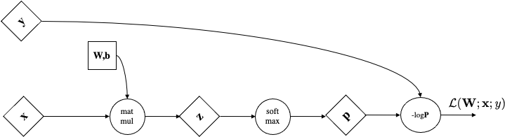